# Download EEA AQ Station Data

Johannes Heisig

2023-10-05

```r
suppressPackageStartupMessages({
  library(dplyr)
  library(tidyr)
  library(sf)
})
```

# Download

Construct URLS like the [EEA discomap service](https://discomap.eea.europa.eu/map/fme/AirQualityExport.htm) that return links to all matching AQ station data CSV files. CSVs each contain stations from 1 country for 1 year and 1 pollutant. `generate_download_urls()` first generates a request, executes it, and writes all matching URLs to file. These can be picked up by `check_station_urls()` to get corresponding country, year, pollutant, and station ID for each entry. Data is finally retrieved with `download_station_data()`.

## Functions

```r
generate_request = function(country, pollutant, year_start, year_end = year_start, source = "All"){
  purrr::map(country, function(c) purrr::map(pollutant, function(p)
    paste0("https://fme.discomap.eea.europa.eu/fmedatastreaming/AirQualityDownload/AQData_Extract.fmw?CountryCode=",
           c, "&CityName=&Pollutant=", p, "&Year_from=", year_start, "&Year_to=",
           year_end, "&Station=&Samplingpoint=&Source=", source,
           "&Output=TEXT&UpdateDate=", year_start, "-01-01&TimeCoverage=Year")
  )) |> purrr::flatten() |> unlist()
}

generate_download_urls = function(country, pollutant, year_start,
                                  year_end = year_start, source = "All",
                                  file = "download_urls.txt", append = F){
  requests = generate_request(country, pollutant, year_start, year_end, source)
  if (!append) file.create(file)
  purrr::map(requests, .f = function(x) curl::curl(x) |>
               readLines() |> write(file, append = T)) |>
    invisible()
  message(paste("Generated", readLines(file) |> length(), "station URLs from",
                length(country), "countries and", length(pollutant),
                "pollutants between", year_start, "and", year_end))
  message("URLs are written to file: ", file)
}

url_meta_data = function(source = "download_urls.txt"){
  if (length(source) == 1){
    u = readLines(source) |> basename()
  } else {
     u = basename(source)
  }
  data.frame(Country = substr(u, 1,2),
             Pollutant = factor(readr::parse_number(u),
                                levels = c(6001, 5, 8, 7),
                                labels = c("PM2.5", "PM10", "NO2", "O3")),
             Year = as.numeric(stringr::str_extract(u, "201[5-9]|202[0-3]")),
             Station = stringr::str_extract(u, "[0-9]{5}"),
             File = u)
}

check_station_urls = function(file = "download_urls.txt", plot = T){
  df = url_meta_data(file)
  smry = dplyr::summarise(df, .by = names(df)[1:3], Count = dplyr::n())
  if (plot) ggplot2::ggplot(smry, ggplot2::aes(Year, Count, fill = Pollutant)) +
    ggplot2::geom_bar(stat = "identity", position = "dodge") +
    ggplot2::facet_wrap(~Country, scales = "free") +
    ggplot2::ggtitle("Number of Stations per Country & Year")
}

download_station_data = function(url_file = "download_urls.txt", dir = NULL){
  stopifnot(file.exists(url_file))
  if (is.null(dir)) dir = file.path(getwd(), "download")
  if (!dir.exists(dir)) dir.create(dir)
  urls = readLines(url_file)
  t = system.time({
  paths = purrr::map(urls, function(u){
    dest = file.path(dir, basename(u))
    if (!file.exists(dest)) curl::curl_download(u, dest)
  }, .progress = list(type = "iterator", name = "Downloading", clear = F)) |> unlist()
  })
  if (t[3] > 5) message("Download took ", t[3] |> unname(), " sec.")
  url_meta_data(urls)
}
```

## Demo

Download AQ data for 3 countries of interest and 4 pollutants of interest:

- Netherlands, Belgium, Luxembourg
- NO2, O3, PM10, PM2.5

```r
countries = c("NL", "BE", "LU")
pollutants = c(7,8,5,6001)

generate_download_urls(countries, pollutants, 2015, 2023)
```

```
## Generated 4998 station URLs from 3 countries and 4 pollutants between 2015 and 2023
```

```
## URLs are written to file: download_urls.txt
```

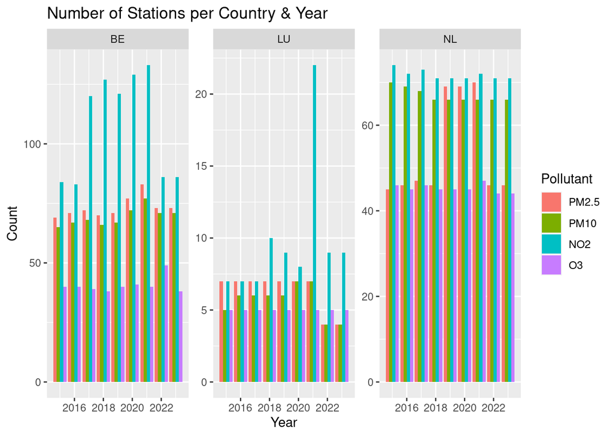

```r
check_station_urls()
```

```r
files = download_station_data()  # ~10 min
```

# Pre-processing

**Quality filter:**

- which [validity classes](http://dd.eionet.europa.eu/vocabulary/aq/observationvalidity/view) should be included?
  - currently 1
- which [verification classes](http://dd.eionet.europa.eu/vocabulary/aq/observationverification/view) should be included?
  - currently 1 & 2

**Station filter:**

## Functions

```r
station_meta = arrow::read_parquet("AQ_stations/EEA_stations_meta.parquet")

read_pollutant = function(files, pollutant = "NO2", countries = NULL, dir = "download"){
  cols = c("AirQualityStationEoICode", "Countrycode", "AirPollutant",
         "Concentration", "DatetimeBegin", "Validity", "Verification")
  files_p = dplyr::filter(files, Pollutant == pollutant, Country %in% countries)
  data = vroom::vroom(file.path(dir, files_p$File), col_select = dplyr::all_of(cols),
                      show_col_types = F)
  tz_shift = (stringr::str_extract(data$DatetimeBegin, " [+-][01][0-9]") |>
                as.numeric()) * 3600 # convert all timestemps to CET
  dplyr::mutate(data, DatetimeBegin = as.POSIXct(DatetimeBegin) + tz_shift,
                AirQualityStationEoICode = as.factor(AirQualityStationEoICode),
                Countrycode = as.factor(Countrycode)) |>
    dplyr::filter(!is.na(Concentration))
}

filter_quality = function(x, keep_validity = 1, keep_verification = c(1,2)){
  dplyr::filter(x, Validity %in% keep_validity,
                Verification %in% keep_verification) |>
    dplyr::select(-Validity, -Verification)
}

add_meta = function(pollutant, meta_data = station_meta){
  p = pollutant$AirPollutant[1]
  meta_data = dplyr::filter(meta_data, AirPollutant == p)
  by =  dplyr::join_by(AirQualityStationEoICode, Countrycode, AirPollutant)
  dplyr::left_join(pollutant, meta_data, by=by)
}

filter_stations = function(x, type = c("background","traffic"),
                           area =  c("rural", "urban", "suburban")){
  dplyr::filter(x, StationType %in% type & StationArea %in% area)
}

pivot_poll = function(x){
  tidyr::pivot_wider(x, names_from = AirPollutant,
              values_from = Concentration, values_fn = max)
}

# join_pollutants = function(pollutants, sf = T){
#   a = add_meta(pollutants[[1]]) |> filter_stations() |> pivot_poll()
#   if (length(pollutants) > 1){
#     by = dplyr::join_by(AirQualityStationEoICode, Countrycode, DatetimeBegin)
#     for (i in 2:length(pollutants)){
#       b = add_meta(pollutants[[i]]) |> filter_stations() |> pivot_poll() |>
#         dplyr::select(AirQualityStationEoICode, Countrycode, DatetimeBegin,setdiff(names(b), names(a)))
#       a = dplyr::full_join(a, b, by = by, suffix = c("", "_2"))
#       suppressWarnings({
#         a$StationArea = pmin(a$StationArea, a$StationArea_2, na.rm = T)
#         a$StationType = pmin(a$StationType, a$StationType_2, na.rm = T)
#       })
#       a = dplyr::select(a, -c(StationArea_2, StationType_2))
#     }
#   }
#   a = dplyr::select(a, AirQualityStationEoICode, Countrycode,
#                     StationArea, StationType, Longitude, Latitude,
#                     Elevation, Population, CLC8,
#                     DatetimeBegin, dplyr::everything()) |>
#     unique()
#   if (sf) a = sf::st_as_sf(a, coords = c("Longitude","Latitude"), crs=4326)
#   return(a)
# }
##########################################

add_meta = function(pollutant, meta_data = station_meta){
  by =  dplyr::join_by(AirQualityStationEoICode, Countrycode)
  dplyr::left_join(pollutant, meta_data, by=by)
}

join_pollutants = function(pollutants, sf = T){
  a = pollutants[[1]] |> pivot_poll()
  if (length(pollutants) > 1){
    by = dplyr::join_by(AirQualityStationEoICode, Countrycode, DatetimeBegin)
    for (i in 2:length(pollutants)){
      b = pollutants[[i]] |> pivot_poll()
      a = dplyr::full_join(a, b, by = by)
    }
  }
  a = add_meta(a) |> filter_stations()
  a = dplyr::select(a, AirQualityStationEoICode, Countrycode,
                    StationArea, StationType, Longitude, Latitude,
                    Elevation, Population, CLC8,
                    DatetimeBegin, dplyr::everything()) |>
    unique()
  if (sf) a = sf::st_as_sf(a, coords = c("Longitude","Latitude"), crs=4326)
  return(a)
}
```

## Demo

Wrangle downloaded CSVs to time series tables with a spatial reference.

1. read and combine files by pollutant
2. apply validation / verification flags

```r
no2 = read_pollutant(files, countries = c("LU")) |> filter_quality()
o3 = read_pollutant(files, pollutant = "O3", countries = c("LU")) |> filter_quality()
pm10 = read_pollutant(files, pollutant = "PM10", countries = c("LU")) |> filter_quality()
pm25 = read_pollutant(files, pollutant = "PM2.5", countries = c("LU")) |> filter_quality()
```

3. join tables to a single time series with measurements of multiple pollutants
4. add station meta data including locations

```r
pollutants = list(no2, o3, pm25, pm10)
poll_table = join_pollutants(pollutants)

summary(poll_table)
```

```
##  AirQualityStationEoICode  Countrycode             StationArea
##  LU0102A:64724            LU     :380048   rural         : 63448
##  LU0101A:64360            AD     :     0   rural-nearcity:     0
##  LU0109A:64327            AL     :     0   rural-regional:     0
##  LU0104A:63448            AT     :     0   rural-remote  :     0
##  LU0111A:37201            BA     :     0   suburban      :  2532
##  LU0110A:35131            BE     :     0   urban         :314068
##  (Other):50857            (Other):     0
##      StationType       Elevation      Population        CLC8
##  background:195064   Min.   :1419   Min.   :  93   HDR    :196390
##  industrial:     0   1st Qu.:2865   1st Qu.:2314   LDR    :118123
##  traffic   :184984   Median :2891   Median :6363   AGR    : 63448
##                      Mean   :2851   Mean   :5053   IND    :  2086
##                      3rd Qu.:2965   3rd Qu.:6727   NAT    :     1
##                      Max.   :3164   Max.   :8208   TRAF   :     0
##                                                    (Other):     0
##  DatetimeBegin                         NO2               O3
##  Min.   :2015-01-01 01:00:00.00   Min.   : -0.30   Min.   :  0.00
##  1st Qu.:2017-04-11 09:00:00.00   1st Qu.: 12.10   1st Qu.: 21.00
##  Median :2018-12-16 08:00:00.00   Median : 23.10   Median : 45.00
##  Mean   :2018-12-23 00:08:09.21   Mean   : 28.09   Mean   : 45.35
##  3rd Qu.:2020-09-05 04:00:00.00   3rd Qu.: 39.40   3rd Qu.: 64.50
##  Max.   :2023-09-25 01:00:00.00   Max.   :249.50   Max.   :228.00
##                                   NA's   :13829    NA's   :197719
##      PM2.5             PM10                 geometry
##  Min.   :  0.00   Min.   :  0.00   POINT        :380048
##  1st Qu.:  6.00   1st Qu.: 13.00   epsg:4326    :     0
##  Median :  9.00   Median : 18.00   +proj=long...:     0
##  Mean   : 10.73   Mean   : 20.25
##  3rd Qu.: 13.23   3rd Qu.: 25.00
##  Max.   :481.00   Max.   :477.00
##  NA's   :203424   NA's   :192925
```

```r
purrr::map_vec(pollutants, nrow)
```

```
## [1] 490559 304537 243978 249644
```

```r
nrow(poll_table)
```

```
## [1] 380048
```

```r
# Station properties
table(poll_table$AirQualityStationEoICode |> droplevels())
```

```
##
## LU0101A LU0102A LU0104A LU0108A LU0109A LU0110A LU0111A LU0112A LU0114A LU0601P
##   64360   64724   63448   32569   64327   35131   37201   13657    2085       1
## LU0602P LU0603P LU0604P LU0605P LU0606P LU0607P LU0608P LU0609P LU0610P LU0611P
##       1       1       1       1       1       1       1       1       1       1
## LU0612P LU0613P LU0614P LU0106A
##       1       1       1    2532
```

```r
table(poll_table$StationArea)
```

```
##
##          rural rural-nearcity rural-regional   rural-remote       suburban
##          63448              0              0              0           2532
##          urban
##         314068
```

```r
table(poll_table$StationType)
```

```
##
## background industrial    traffic
##     195064          0     184984
```

```r
geoarrow::write_geoparquet(poll_table,  "AQ_data/LU_hourly_2015-2023_gaps_sf.parquet")
cbind(st_drop_geometry(poll_table),
      st_coordinates(poll_table) |> as_tibble() |> setNames(c("Longitude","Latitude"))) |>
  arrow::write_parquet("AQ_data/LU_hourly_2015-2023_gaps.parquet")
```